# Project 1

## Orders

This is a bar graph showing the number of orders placed by a customer with a certain customer id.

```
## stat_bin: binwidth defaulted to range/30. Use 'binwidth = x' to adjust this.
```

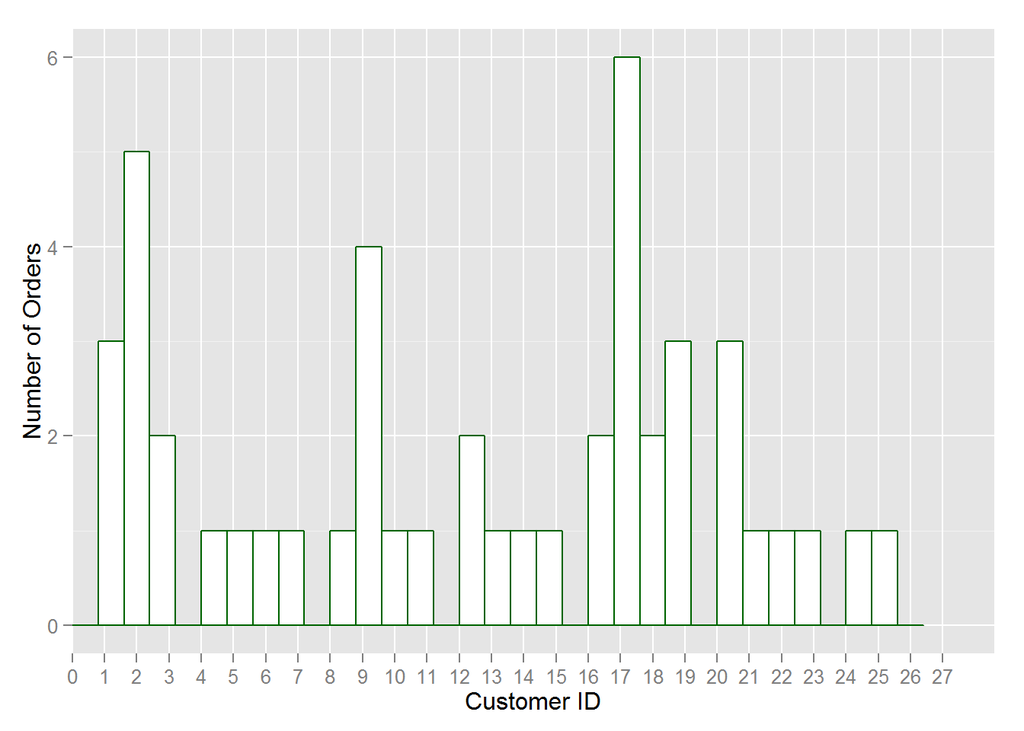

## Order details

This graph shows the frequency of which each quantity of each item was sold. EX: One copy of Umani in Concert was ordered 10 times, and two copies of Umani in Comcers were ordered once.

[output not shown]

[output cut: 407 more lines]

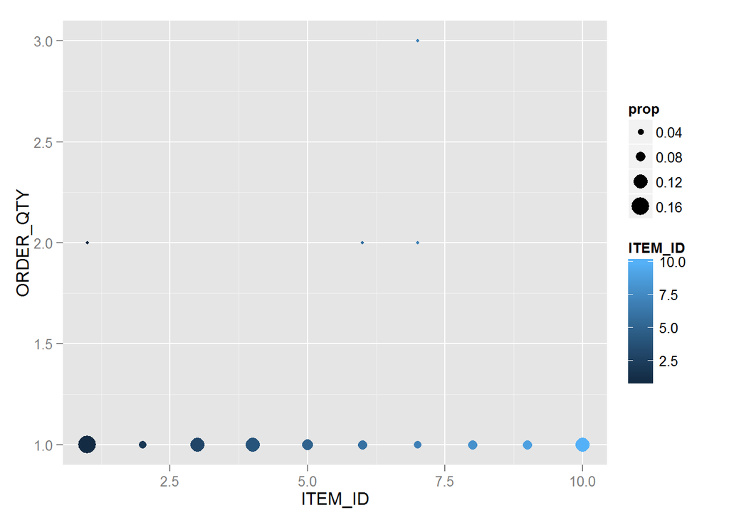

## Reproducing given plots with accompanying R code

Here are the plots with the R code used to recreat them.

Graph of order date by shipping date colored by unit price

### R code:

ggplot(fulldf, aes(x = as.Date(ORDER_DATE, “%Y-%m-%d”), y = as.Date(SHIPPED_DATE, “%Y-%m-%d”), colour = as.factor(UNIT_PRICE))) + geom_point() + facet_wrap(~ CUSTOMER_STATE)

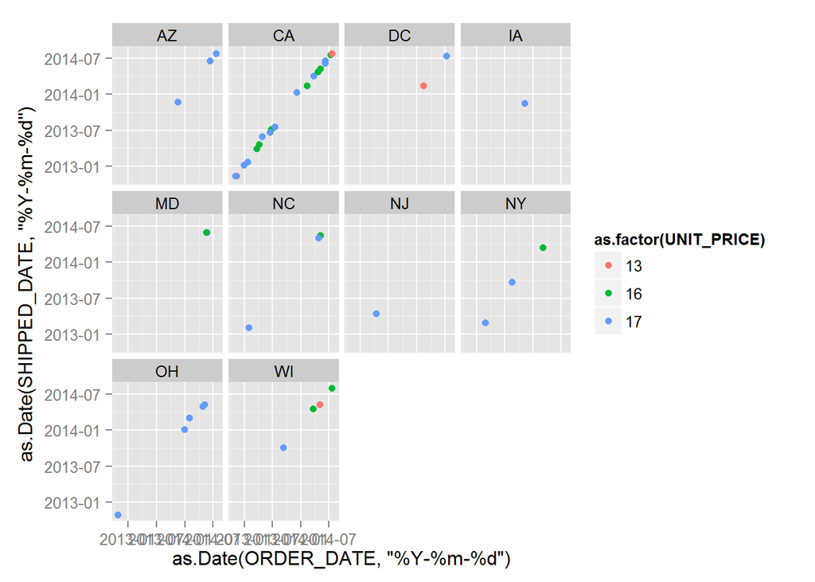

Graph of order date by shipping date colored by title of item

### R code:

ggplot(fulldf, aes(x = as.Date(ORDER_DATE, “%Y-%m-%d”), y = as.Date(SHIPPED_DATE, “%Y-%m-%d”), colour = as.factor(TITLE))) + geom_point() + facet_wrap(~ CUSTOMER_STATE)

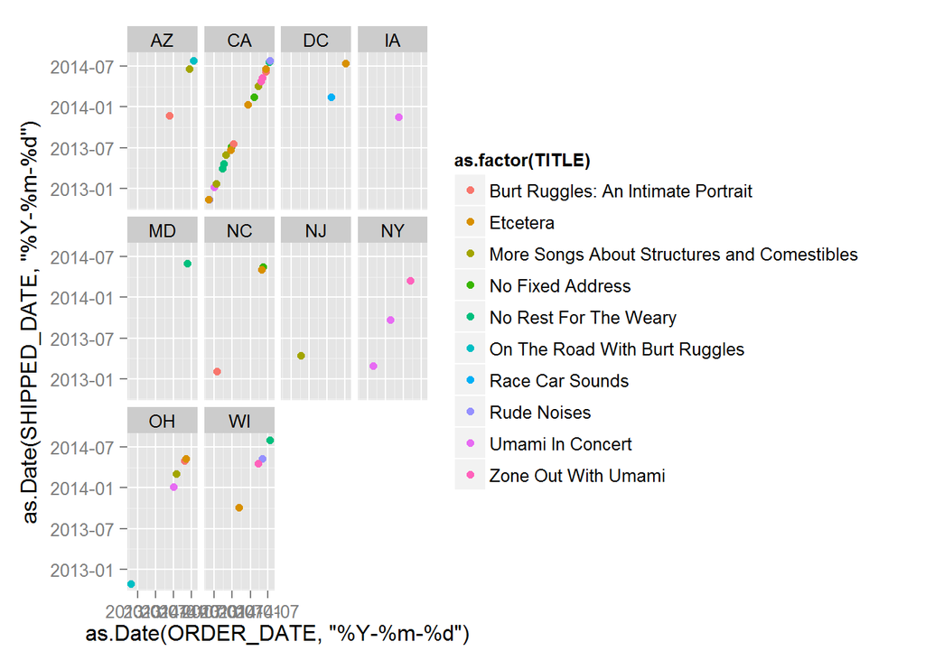

Graph of order date by shipping date colored by artist

### R code:

ggplot(fulldf, aes(x = as.Date(ORDER_DATE, “%Y-%m-%d”), y = as.Date(SHIPPED_DATE, “%Y-%m-%d”), colour = as.factor(ARTIST))) + geom_point() + facet_wrap(~ CUSTOMER_STATE)

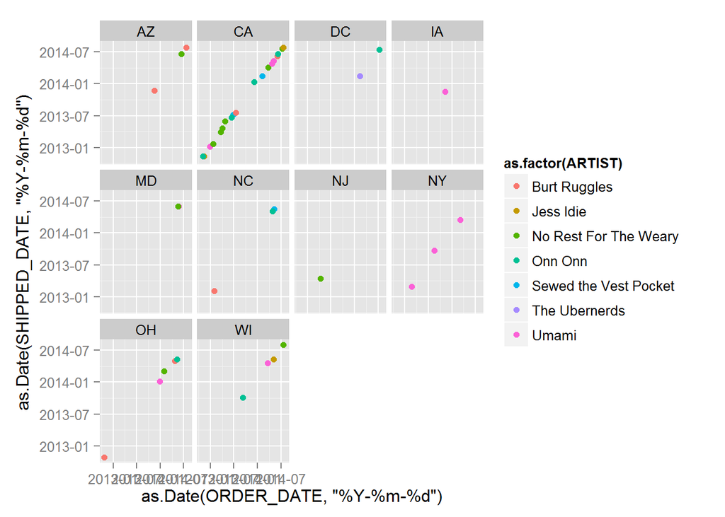